# Отчет по лабораторной работе №3

Настройка DHCP-сервера

Виноградова М.А

Российский университет дружбы народов, Москва, Россия

19 сентября 2025

# Информация

## Докладчик

- Виноградова Мария Андреевна
- студентка НПИбд-02-24
- номер студ. билета 1132240691
- Российский университет дружбы народов
- 1132240691@pfur.ru
- https://github.com/mavinogradova/study_2025-2026_os2

# Цель работы

Приобретение практических навыков по установке и конфигурированию DHCP-сервера.

# Задание

1. Установить на виртуальной машине server DHCP-сервер.
2. Настроить виртуальную машину server в качестве DHCP-сервера для виртуальной внутренней сети.
3. Получить параметры от DHCP-сервера в виртуальной внутренней сети путём запуска виртуальной машины client и применения соответствующих утилит диагностики.
4. Настроить обновление DNS-зоны при появлении в виртуальной внутренней сети новых узлов.
5. Проверить корректность работы DHCP-сервера и обновления DNS-зоны в виртуальной внутренней сети путём запуска виртуальной машины client и применения соответствующих утилит диагностики.
6. Написать скрипт для Vagrant, фиксирующий действия по установке и настройке DHCP-сервера во внутреннем окружении виртуальной машины server. Внести соответствующие изменения в Vagrantfile.

# Выполнение лабораторной работы

# Подключение к виртуальной машине server

## Запускаем виртуальную машину server и подключаемся к ней по SSH.

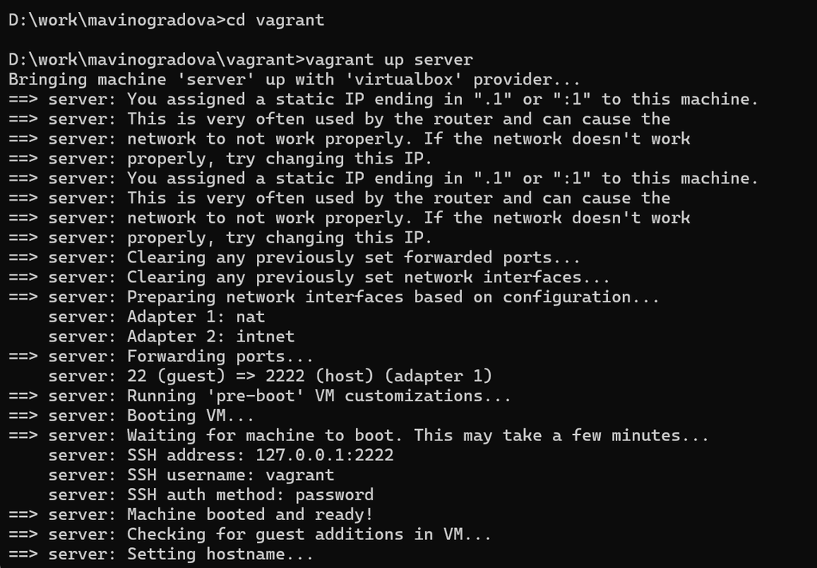

Запуск виртуальной машины server

# Установка DHCP-сервера

## Входим под пользователем `mavinogradova` и переходим в режим суперпользователя.

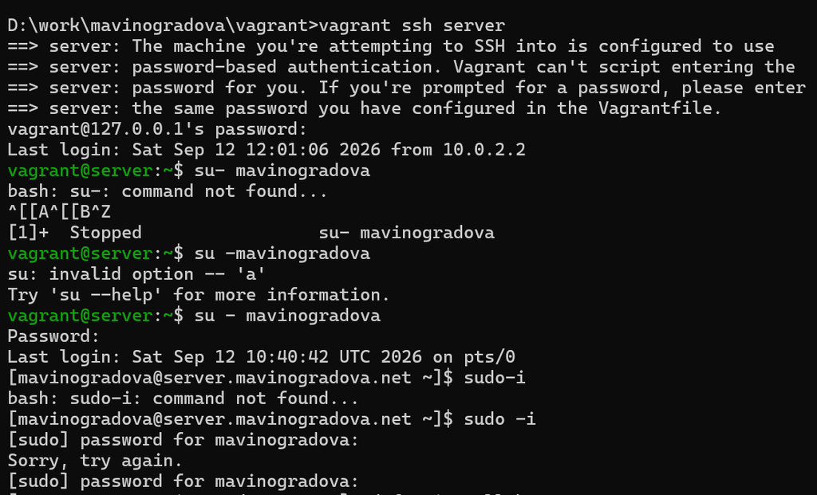

Вход под mavinogradova и получение root

## Устанавливаем DHCP-сервер Kea.

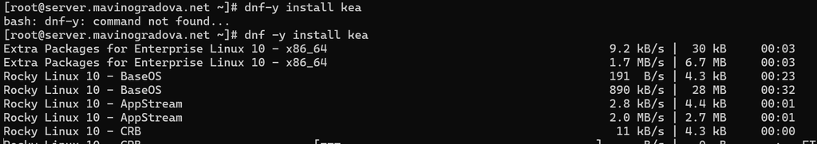

Установка kea

# Конфигурирование DHCP-сервера

## Сохраняем резервную копию конфигурационного файла и открываем его на редактирование.

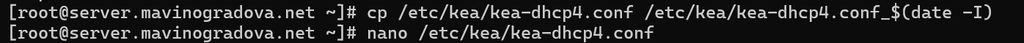

Резервная копия kea-dhcp4.conf

## Анализируем содержимое `/etc/kea/kea-dhcp4.conf`.

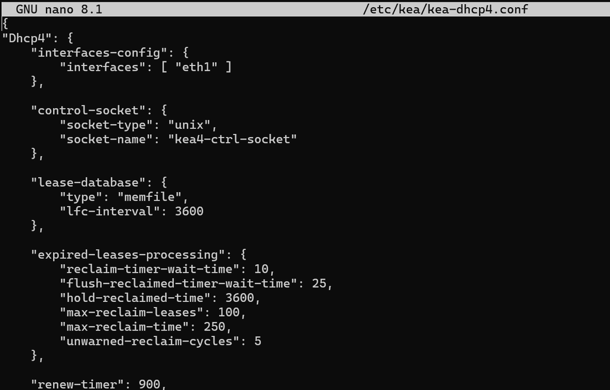

Содержимое kea-dhcp4.conf

## Задаём конфигурацию DHCP-сети и проверяем конфигурационный файл.

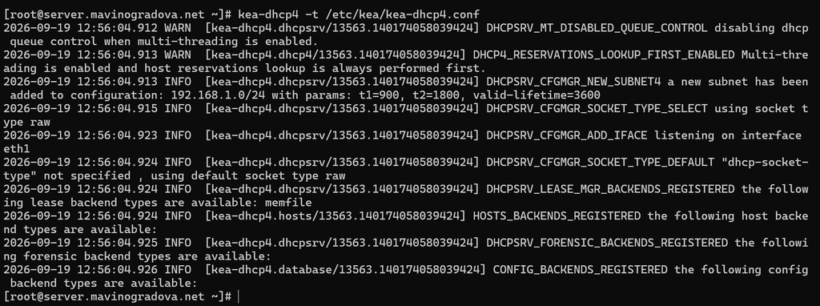

Проверка конфигурационного файла

## Перезагружаем конфигурацию dhcpd и включаем автозапуск.

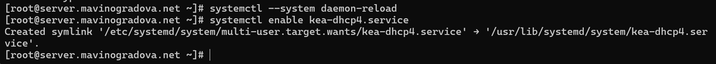

Перезагрузка конфигурации и включение автозапуска

## Добавляем запись для DHCP-сервера в DNS-зоны (прямую и обратную).

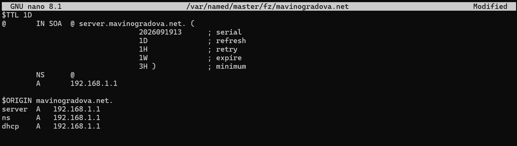

Прямая DNS-зона mavinogradova.net

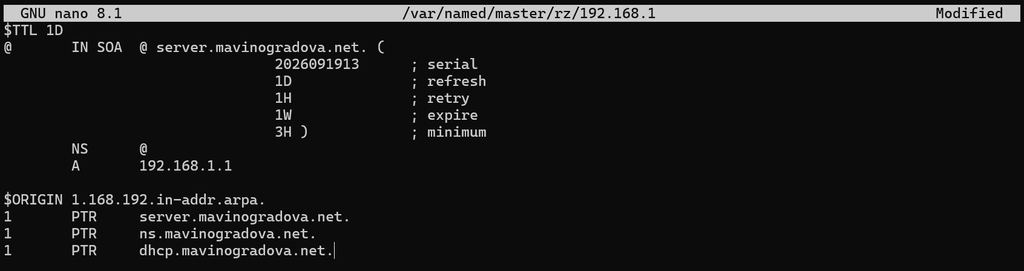

Обратная DNS-зона 192.168.1

## Перезапускаем named и проверяем ping dhcp.mavinogradova.net.

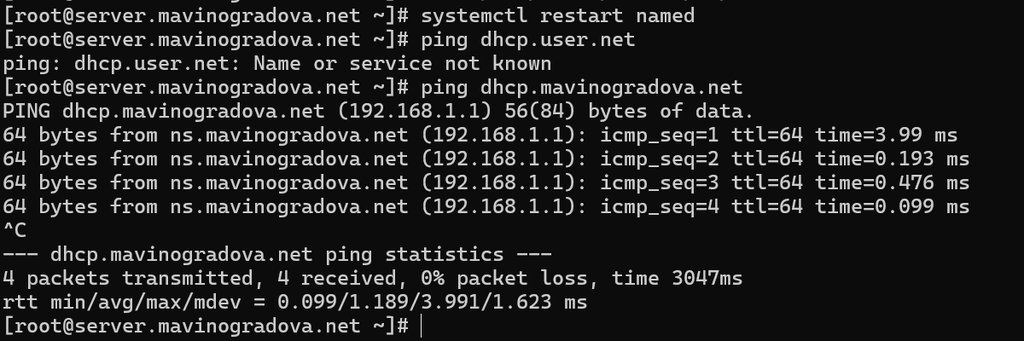

Перезапуск named и проверка ping dhcp.mavinogradova.net

## Разрешаем работу с DHCP в межсетевом экране.

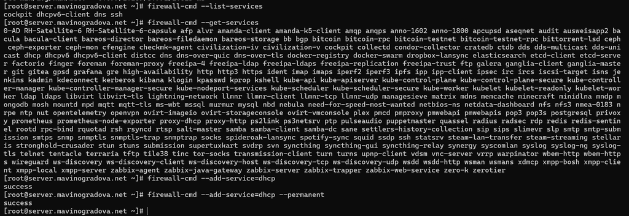

Разрешение DHCP в firewall

## Восстанавливаем контекст безопасности в SELinux.

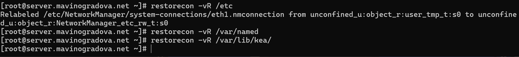

Восстановление контекста SELinux

## Запускаем мониторинг системных сообщений.

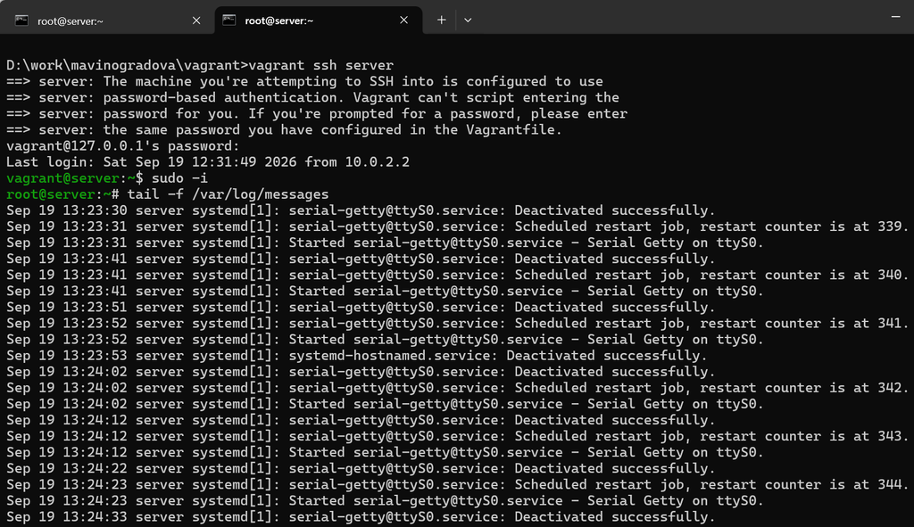

Мониторинг системных сообщений

## Запускаем DHCP-сервер и убеждаемся в успешном запуске.

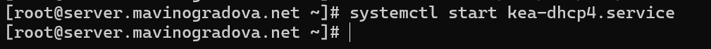

Запуск DHCP-сервера

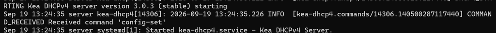

Запуск kea-dhcp4.service

# Анализ работы DHCP-сервера

## Создаём файл `01-routing.sh` в каталоге provision/client.

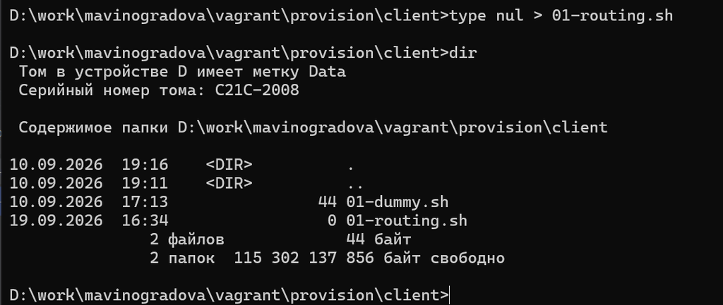

Создание файла 01-routing.sh

## Прописываем в нём скрипт, изменяющий настройки NetworkManager.

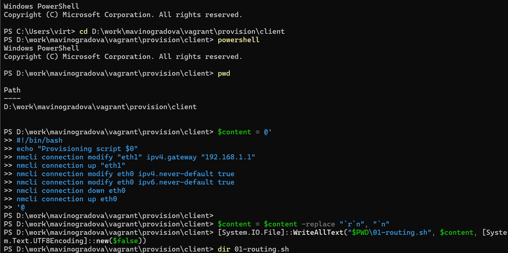

Содержимое 01-routing.sh

## Подключаем скрипт в `Vagrantfile` в разделе конфигурации для клиента.

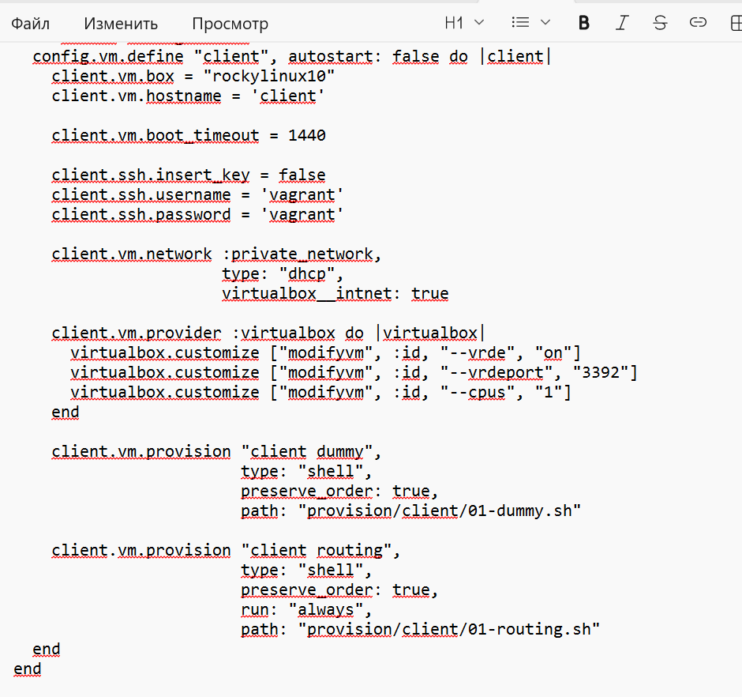

Фрагмент Vagrantfile с client routing